# WeRateDogs Analysis

## They're statistically significant breeds, Brent

**Author:** Ken Norton (ken@kennethnorton.com)

[figure not shown]

The [WeRateDogs Twitter account (@dog_rates)](https://twitter.com/dog_rates) has a simple premise: they take photos of peoples' dogs and rate them on a 1-10 scale, often rating dogs well above 10. Since its inception in 2015, the account has grown to more than 8 million followers.

WeRateDogs went mainstream – and launched a meme – during a notorious exchange in 2016, when, as described by *Know Your Meme*, "Twitter user @brant took issue with the account's rating system, tweeting @dog_rates to tell them it didn't make any sense. @dog_rates replied with 'they're good dogs Brent,' purposefully misspelling @brant's name."

[figure not shown]

WeRateDogs was right, they are good dogs. But are some breeds of dog *more good* than others? We set out to answer that question and put our top data analyst on the task.

First, we downloaded a complete archive of the @dog_rates Twitter history. Then, we sent all of the images through a neural network that classified dogs by their breeds. The top breeds rated by @dog_rates are:

| Breed | # of Tweets |
| --- | --- |
| Golden Retriever | 116 |
| Pembroke (Welsh Corgi) | 70 |
| Labrador Retriever | 63 |
| Chihuahua | 47 |
| Pug | 43 |
| Samoyed | 29 |
| Pomeranian | 29 |
| Chow | 26 |
| Toy Poodle | 24 |
| French Bulldog | 21 |

When we examined WeRateDogs' unique rating system, we didn't find any statistically significant difference in how dogs were rated. It seems WeRateDogs likes all dogs equally.

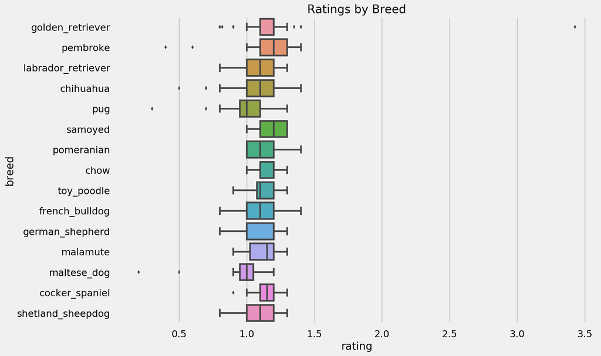

But what about WeRateDogs' followers? They they like certain breeds more than others? To answer that question, we looked at favorites ("likes") and retweets. Here are the top ten breeds when it comes to who other users favorite and retweet:

| Breed | Average # of Faves + RTs |
| --- | --- |
| French Bulldog | 23,265 |
| Labrador Retriever | 17,375 |
| Samoyed | 16,704 |
| Pembroke (Welsh Corgi) | 15,973 |
| Golden Retriever | 15,496 |
| Cocker Spaniel | 15,097 |
| Chow | 14,217 |
| Malamute | 13,504 |
| German Shepherd | 12,283 |
| Chihuahua | 12,274 |

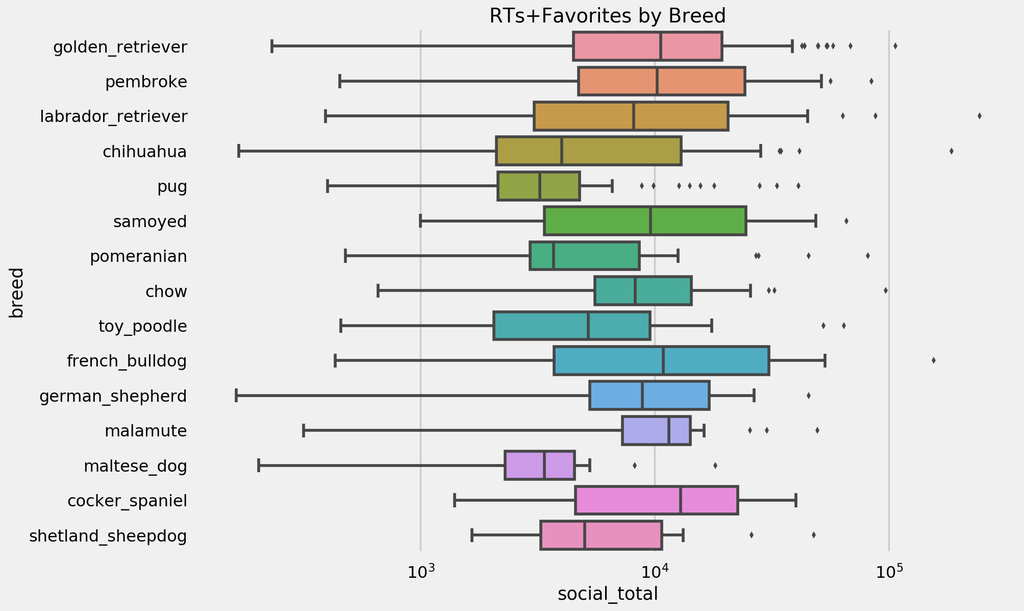

The French Bulldogs appears to be most popular with followers, despite being only the 10th most popular breed shared. Our data analyst crunched the numbers and confirmed it: French Bulldogs, along with Pembrokes, Labrador Retrievers, Samoyeds, and Golden Retrievers are statistically more likely to receive more likes and retweets than other breeds.

Now we know!

[figure not shown]